# Raport - śledzie

FW

30 listopad, 2016

# 1 Wstęp

Celem badania jest sprawdzenie przyczyny zmniejszenia się długości śledzi oceanicznych wyławianych na terenie Europy. W kolejnych rozdziałach zostały zaprezentowane wartości zmierzonych atrybutów, następnie pokazano podstawowe statystyki dotyczące poszczególnych pomiarów. W ostatnim rozdziale zbudowany został regresor, którego zadaniem jest przewidywanie długości śledzia na podstawie innych pomiarów. Z uzyskanego modelu wynika, że prawdopodobną przyczyną zmniejszenia się długości śledzia jest zmiana temperatury przy powierzchni wody. Ponadto, z analizy ważności atrybutów wynika, że na rozmiar śledzi wpływ ma przede wszystkim klimat, a nie bezpośrednia działalność człowieka.

# 2 Wstępne przetwarzanie danych

## 2.1 Użyte biblioteki i przygotowanie zbioru danych

Wykorzystano następujące biblioteki:

```r
# manage data
library(dplyr)
library(tidyr)
# plotting
library(ggplot2)
library(plotly)
# manage NA's
library(zoo)
# melt correlation
library(reshape2)
# regression
library(caret) # <- install.packages("caret", dependencies = c("Depends", "Suggests"))
```

Surowe dane zawierają 52582 próbek (wierszy) oraz 16 atrybutów (kolumn).

W celu uzupełnienia brakujących wartości zastosowano metodę locf() z biblioteki zoo, która uzupełnia wartości NA na podstawie komórki znajdującej się w poprzednim wierszu. Wiersze, w których po tej operacji wartości NA pozostały (np pierwszy wiersz), są usuwane.

## 2.2 Podsumowanie rozmiaru zbioru i podstawowe statystyki

Dane po przetworzeniu i uzupełnieniu brakujących wartości zawierają 52581 próbek (wierszy) oraz 16 atrybutów (kolumn).

W poniższej tabeli przedstawiono kilka pierwszych wierszy z tabeli:

| X | length | cfin1 | cfin2 | chel1 | chel2 | lcop1 | lcop2 | fbar | recr | cumf | totaln | sst | sal | xmonth | nao |
| --- | --- | --- | --- | --- | --- | --- | --- | --- | --- | --- | --- | --- | --- | --- | --- |
| 1 | 22.5 | 0.02778 | 0.27785 | 2.46875 | 21.43548 | 2.54787 | 26.35881 | 0.356 | 482831 | 0.3059879 | 267380.8 | 14.30693 | 35.51234 | 7 | 2.8 |
| 2 | 25.0 | 0.02778 | 0.27785 | 2.46875 | 21.43548 | 2.54787 | 26.35881 | 0.356 | 482831 | 0.3059879 | 267380.8 | 14.30693 | 35.51234 | 7 | 2.8 |
| 3 | 25.5 | 0.02778 | 0.27785 | 2.46875 | 21.43548 | 2.54787 | 26.35881 | 0.356 | 482831 | 0.3059879 | 267380.8 | 14.30693 | 35.51234 | 7 | 2.8 |
| 4 | 24.0 | 0.02778 | 0.27785 | 2.46875 | 21.43548 | 2.54787 | 26.35881 | 0.356 | 482831 | 0.3059879 | 267380.8 | 14.30693 | 35.51234 | 7 | 2.8 |
| 5 | 22.0 | 0.02778 | 0.27785 | 2.46875 | 21.43548 | 2.54787 | 26.35881 | 0.356 | 482831 | 0.3059879 | 267380.8 | 14.30693 | 35.51234 | 7 | 2.8 |
| 6 | 24.0 | 0.02778 | 0.27785 | 2.46875 | 21.43548 | 2.54787 | 26.35881 | 0.356 | 482831 | 0.3059879 | 267380.8 | 14.30693 | 35.51234 | 7 | 2.8 |

Oznaczenia kolumn:

- X: numer badania (chronologicznie) wyznaczający upływ czasu;
- length: długość złowionego śledzia [cm];
- cfin1: dostępność planktonu [zagęszczenie Calanus finmarchicus gat. 1];
- cfin2: dostępność planktonu [zagęszczenie Calanus finmarchicus gat. 2];
- chel1: dostępność planktonu [zagęszczenie Calanus helgolandicus gat. 1];
- chel2: dostępność planktonu [zagęszczenie Calanus helgolandicus gat. 2];
- lcop1: dostępność planktonu [zagęszczenie widłonogów gat. 1];
- lcop2: dostępność planktonu [zagęszczenie widłonogów gat. 2];
- fbar: natężenie połowów w regionie [ułamek pozostawionego narybku];
- recr: roczny narybek [liczba śledzi];
- cumf: łączne roczne natężenie połowów w regionie [ułamek pozostawionego narybku];
- totaln: łączna liczba ryb złowionych w ramach połowu [liczba śledzi];
- sst: temperatura przy powierzchni wody [°C];
- sal: poziom zasolenia wody [Knudsen ppt];
- xmonth: miesiąc połowu [numer miesiąca];
- nao: oscylacja północnoatlantycka [mb].

Poniżej przedstawiono statystyki poszczególnych kolumn:

|  | X | length | cfin1 | cfin2 | chel1 | chel2 | lcop1 | lcop2 | fbar | recr | cumf | totaln | sst | sal | xmonth | nao |
| --- | --- | --- | --- | --- | --- | --- | --- | --- | --- | --- | --- | --- | --- | --- | --- | --- |
|  | Min. : 1 | Min. :19.0 | Min. : 0.0000 | Min. : 0.0000 | Min. : 0.000 | Min. : 5.238 | Min. : 0.3074 | Min. : 7.849 | Min. :0.0680 | Min. : 140515 | Min. :0.06833 | Min. : 144137 | Min. :12.77 | Min. :35.40 | Min. : 1.000 | Min. :-4.89000 |
|  | 1st Qu.:13146 | 1st Qu.:24.0 | 1st Qu.: 0.0000 | 1st Qu.: 0.2778 | 1st Qu.: 2.469 | 1st Qu.:13.427 | 1st Qu.: 2.5479 | 1st Qu.:17.808 | 1st Qu.:0.2270 | 1st Qu.: 360061 | 1st Qu.:0.14809 | 1st Qu.: 306068 | 1st Qu.:13.60 | 1st Qu.:35.51 | 1st Qu.: 5.000 | 1st Qu.:-1.89000 |
|  | Median :26291 | Median :25.5 | Median : 0.1111 | Median : 0.7012 | Median : 5.750 | Median :21.435 | Median : 7.0000 | Median :24.859 | Median :0.3320 | Median : 421391 | Median :0.23191 | Median : 539558 | Median :13.86 | Median :35.51 | Median : 8.000 | Median : 0.20000 |
|  | Mean :26291 | Mean :25.3 | Mean : 0.4463 | Mean : 2.0255 | Mean :10.004 | Mean :21.218 | Mean : 12.8029 | Mean :28.423 | Mean :0.3304 | Mean : 520367 | Mean :0.22981 | Mean : 514978 | Mean :13.87 | Mean :35.51 | Mean : 7.258 | Mean :-0.09241 |
|  | 3rd Qu.:39436 | 3rd Qu.:26.5 | 3rd Qu.: 0.3333 | 3rd Qu.: 1.7936 | 3rd Qu.:11.500 | 3rd Qu.:27.193 | 3rd Qu.: 21.2315 | 3rd Qu.:37.232 | 3rd Qu.:0.4560 | 3rd Qu.: 724151 | 3rd Qu.:0.29803 | 3rd Qu.: 730351 | 3rd Qu.:14.16 | 3rd Qu.:35.52 | 3rd Qu.: 9.000 | 3rd Qu.: 1.63000 |
|  | Max. :52581 | Max. :32.5 | Max. :37.6667 | Max. :19.3958 | Max. :75.000 | Max. :57.706 | Max. :115.5833 | Max. :68.736 | Max. :0.8490 | Max. :1565890 | Max. :0.39801 | Max. :1015595 | Max. :14.73 | Max. :35.61 | Max. :12.000 | Max. : 5.08000 |

# 3 Analiza danych

## 3.1 Wykresy atrybutów

Poniższe wykresy przedstawiają zmianę poszczególnych atrybutów w czasie.

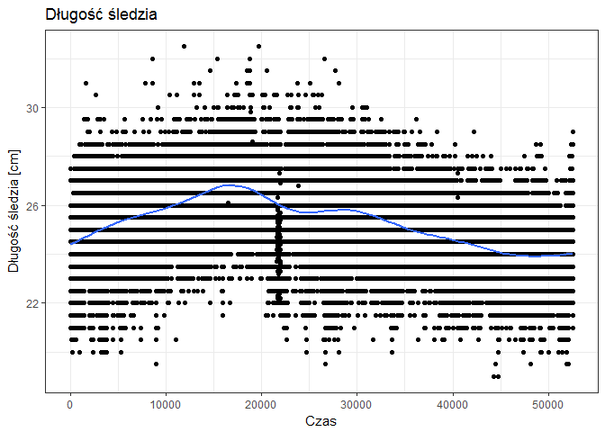

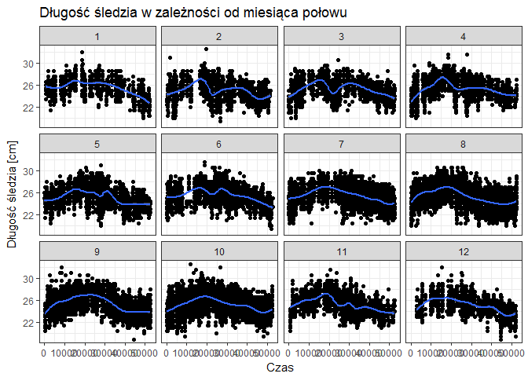

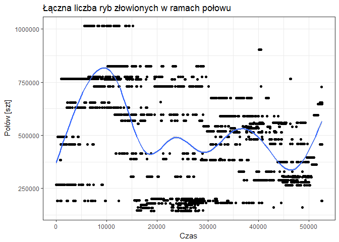

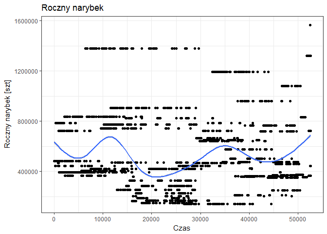

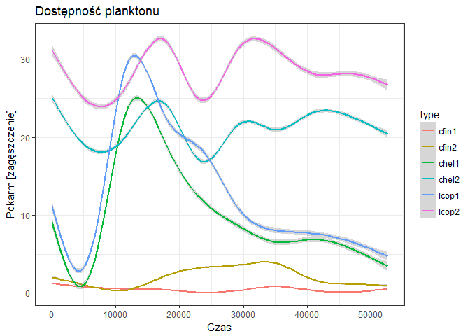

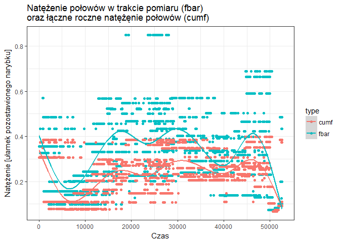

Inne czynniki środowiskowe:

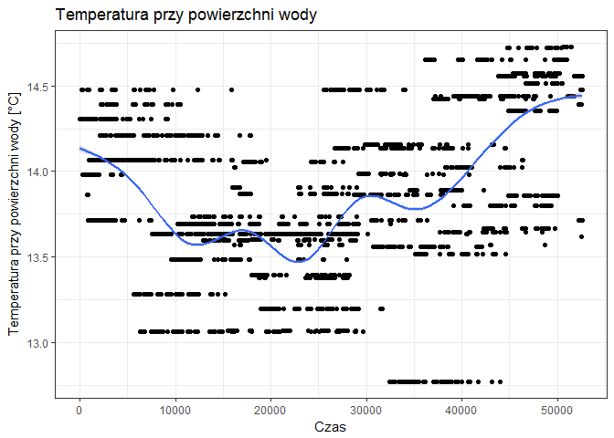

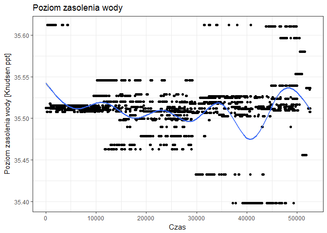

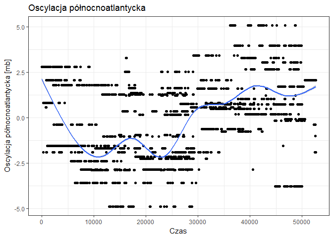

## 3.2 Korelacja

Wykres przedstawia korelację Pearsona pomiędzy poszczególnymi zmierzonymi atrybutami:

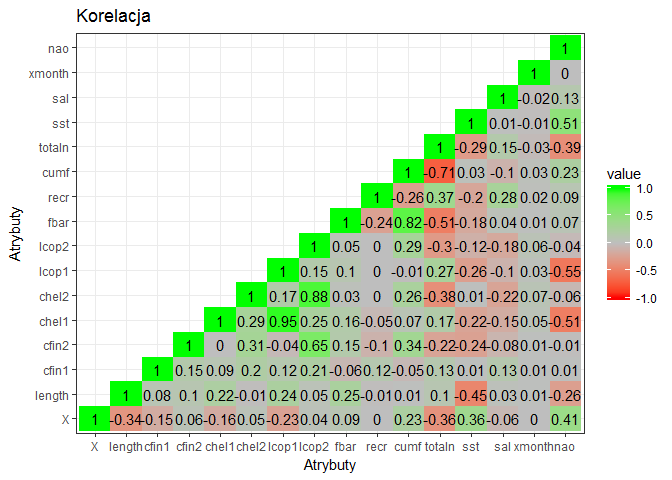

## 3.3 Interaktywny wykres

Poniższy wykres pozwala na zapoznanie się ze zmianą rozmiaru śledzia w czasie z dokładnością do pojedynczego momentu w czasie:

[interactive chart not shown]

# 4 Regresor

## 4.1 Przewidywanie rozmiaru śledzia

W tym rozdziale, na podstawie wiedzy pozyskanej z wstępnej analizy danych, spróbowano stworzyć regresor przewidujący rozmiar śledzia w zależności od wartości atrybutów.

Zbiór został podzielony na dane uczące, walidujące (75%) i testowe (25%) w taki sposób, aby zachować równomierny rozkład danych w zbiorach - atrybutem stratyfikującym jest rozmiar śledzia. Do przygotowania zbiorów użyto metody powtórzonej oceny krzyżowej z liczbą podziałów równą 2 oraz 3 powtórzeniami.

Trafność regresji szacowana jest na podstawie miar R2 oraz RMSE.

Poniżej przedstawiono rezultaty fazy uczącej:

```
## Random Forest
##
## 39438 samples
##    15 predictor
##
## No pre-processing
## Resampling: Cross-Validated (2 fold, repeated 3 times)
## Summary of sample sizes: 19719, 19719, 19720, 19718, 19720, 19718, ...
## Resampling results across tuning parameters:
##
##   mtry  RMSE      Rsquared
##    2    1.139389  0.5244018
##    8    1.102547  0.5557599
##   15    1.194154  0.5023622
##
## RMSE was used to select the optimal model using  the smallest value.
## The final value used for the model was mtry = 8.
```

Poniższe miary wskazują na jakość predykcji:

```
##      RMSE  Rsquared
## 1.0748702 0.5790846
```

Wartość miary RMSE powinna być jak najbliższa wartości 1, natomiast znaczenie metryki R2 jest następujące:

- 0,0 - 0,5 - dopasowanie niezadowalające
- 0,5 - 0,6 - dopasowanie słabe
- 0,6 - 0,8 - dopasowanie zadowalające
- 0,8 - 0,9 - dopasowanie dobre
- 0,9 - 1,0 - dopasowanie bardzo dobre

Poniższe wykresy prezentują skuteczność przewidywań w odniesieniu do danych testowych:

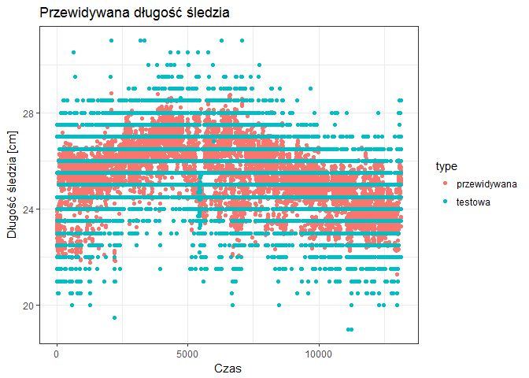

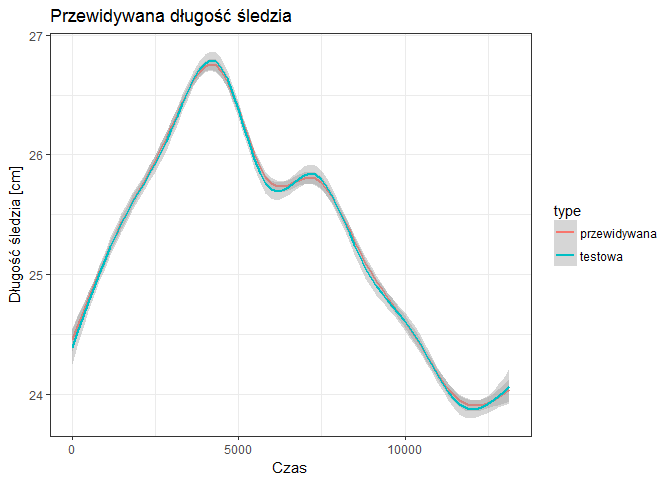

Wykres funkcji przewidującej długość śledzia w znacznym stopniu pokrywa się z wykresem stworzonym na bazie danych testowych.

## 4.2 Analiza ważności atrybutów

Poniższy wykres pokazuje poziom ważności atrybutów w modelu użytym do predykcji rozmiaru śledzi:

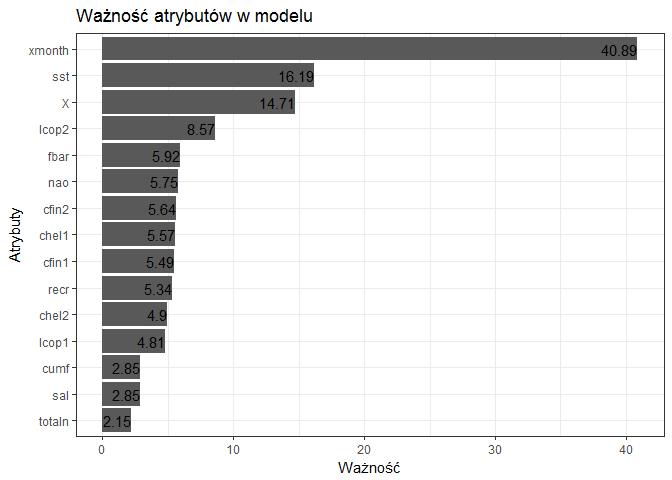

Z analizy ważności atrybutów wynika, że na rozmiar śledzia w największym stopniu ma wpływ miesiąc połowu oraz temperatura przy powierzchni wody. Drugi z atrybutów jest jednocześnie najbardziej skorelowany z długością śledzia. Jednakże sam fakt występowania korelacji nie implikuje przyczynowości, tzn. nie można na podstawie korelacji stwierdzić, że zmiana temperatury przy powierzchni wody miała wpływ na zmniejszenie rozmiaru śledzi. Istnieje jednak szansa, że zmiany wystąpiły jednocześnie przez przypadek. Kolejnym skorelowanym z długością śledzia atrybutem jest oscylacja północnoatlantycka.

Podsumowując, z powyższych badań wynika, że zmiana długości śledzia jest spowodowana przede wszystkim zmianami klimatycznymi - podwyższeniem temperatury wody, a bezpośrednia działalność człowieka (intensywność połowów) nie ma w tym przypadku znaczenia. Nie można jednak na podstawie powyższej analizy stwierdzić, czy działalność człowieka nie ma pośredniego wpływu na klimat, który z kolei ma wpływ na rozmiar śledzi.